# healthData package for data analysis

Jing Wang

12/13/2017

### Motivation

I have always been interested in how daily habits(eating, exercising, etc) can change my daily weight. Therefore, I created a self daily survey tring to answer what factors can significantly infulence my weight and how (positive? or negative?). I thought about some factor that might play a role in weight increase and weight decrease. They are: olive oil taken (perday), red meat taken (perday), other proteins taken (perday), protein in total (perday), vegetables taken (perday), rice and grain taken (perday), water in cups taken (perday), snacks taken (perday), fitness time, study hours, entertainment hours,sleep hours. This package is designed for analysis on how these factors will influence my daily weight.

### Data collection

Once I decide the variables that might influence my weight, I collected data for each factor every day. For diet(red meat, other protein, rice and grain, vagetables, oil,snack), I used food scale to weigh them.For water, I used a cup (around 400ML/cup) to record daily water taking. In addition, I record the durations for fitness, study, entertainment and sleeping.

[output not shown]

### Import data from google sheet

I read my Personal Health Data Sheet from google sheet

### Take a first look at the dataset

```r
knitr::kable(head(mydata), format = "markdown", align = 'c', caption = "Personal Health Data Sheet")
```

| Date | Weight (in kg) | Olive oil (in g) | Red Meat (in g) | Other Proteins (in g) | Protein in total (in g) | Vegetables (in g) | Rice and Grain (in g) | Water (in cup) | Snacks (in calories) | Fitness (in mins) | Study Hours (in hrs) | Entertament (in hrs) | Sleep Hours (in hrs) |
| --- | --- | --- | --- | --- | --- | --- | --- | --- | --- | --- | --- | --- | --- |
| 09/13/2017 | 60.0 | 20 | 300 | 0 | 300 | 500 | 100 | 6.0 | 0 | 0 | 4 | 3.0 | 9.0 |
| 09/14/2017 | 60.4 | 18 | 500 | 0 | 500 | 350 | 72 | 7.0 | 0 | 0 | 5 | 2.0 | 8.0 |
| 09/15/2017 | 60.8 | 12 | 400 | 200 | 600 | 320 | 163 | 5.0 | 120 | 30 | 5 | 3.0 | 8.5 |
| 09/16/2017 | 60.8 | 15 | 200 | 300 | 500 | 400 | 94 | 5.0 | 260 | 0 | 7 | 1.0 | 8.0 |
| 09/17/2017 | 60.4 | 15 | 0 | 301 | 301 | 550 | 137 | 5.5 | 50 | 20 | 5 | 2.0 | 9.0 |
| 09/18/2017 | 60.1 | 10 | 50 | 100 | 150 | 580 | 98 | 7.5 | 30 | 0 | 10 | 0.5 | 7.5 |

### Briefly know my life habit by getting the avarage for each column

```r
mydataMean=as.data.frame(round(apply(mydata[c(0:15),c(2:14)],2,mean),1))
colnames(mydataMean)[1]="Mean"
knitr::kable(mydataMean, format = "markdown", caption = "average life habit")
```

|  | Mean |
| --- | --- |
| Weight (in kg) | 60.5 |
| Olive oil (in g) | 15.8 |
| Red Meat (in g) | 145.3 |
| Other Proteins (in g) | 243.4 |
| Protein in total (in g) | 388.7 |
| Vegetables (in g) | 405.0 |
| Rice and Grain (in g) | 113.6 |
| Water (in cup) | 5.8 |
| Snacks (in calories) | 67.5 |
| Fitness (in mins) | 11.3 |
| Study Hours (in hrs) | 6.0 |
| Entertament (in hrs) | 2.1 |
| Sleep Hours (in hrs) | 8.3 |

From this result, I can see that my eating habit is good(eating lots of vegetables, intake proteins and grains, drink lots of water and not too much snacks). Also, the average sleep time is health (over 8hrs each day). However, I can see my bad life habit is not enough excercises(average is only 11 mins everyday).

### Box plot

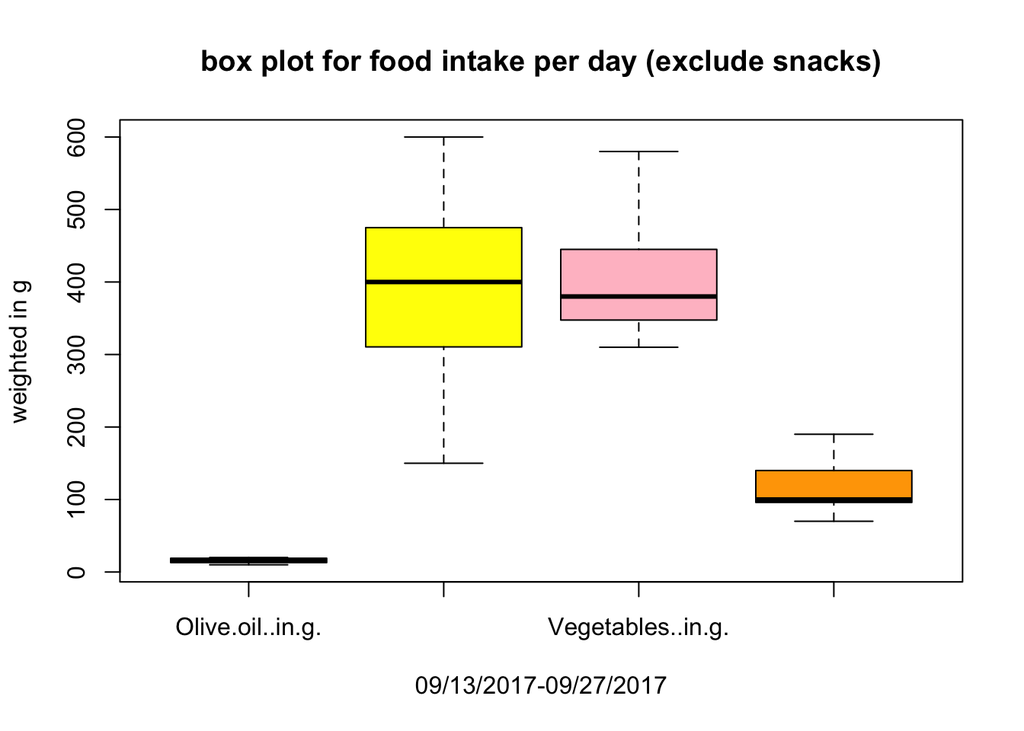

```r
boxplotdata= list("oliveOoil"= mydata[1:15, ][3],"totalProtein"= mydata[1:15, ][6],"vegetables" = mydata[1:15, ][7],"riceGgrain" = mydata[1:15, ][8])
boxplotdataframe=as.data.frame(boxplotdata)
boxplot(boxplotdataframe,col=c("blue","yellow","pink","orange"),main="box plot for food intake per day (exclude snacks)",xlab="09/13/2017-09/27/2017",ylab="weighted in g")
```

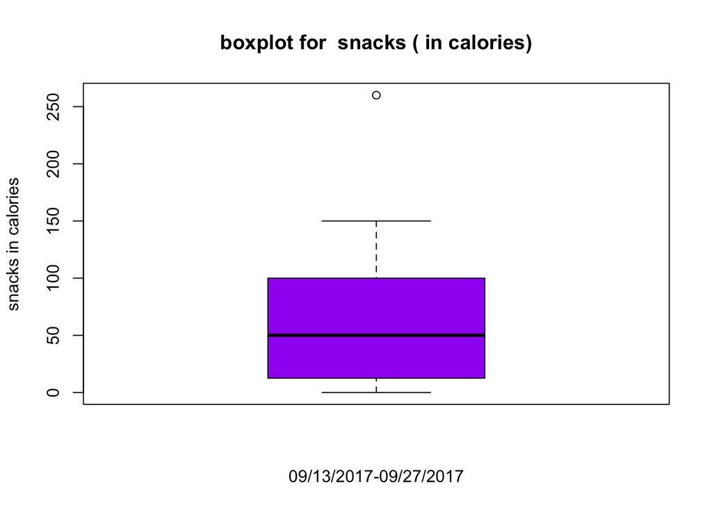

```r
boxplot(mydata[1:15, ][10], main="boxplot for  snacks ( in calories)", ylab="snacks in calories",xlab="09/13/2017-09/27/2017",col="purple")
```

From the boxplot I can see my diet data is not too dispersed. There are only outliers for snacks. The outlier for this snack was becuase of database project due. I some times intake lots of snacks when I feel too much pressure, which is not healthy. Also, the range for rice and grain is large but the average is relatively low. This reflects that rice and grain are not stable in my diet and mostly I don’t like them.

### Pearson’s correlation coefficient

```r
library(healthDataPackage)
multiCorTest(mydata,"Weight (in kg)")
```

|  | correlation |
| --- | --- |
| Weight (in kg) | 1.00 |
| Olive oil (in g) | 0.08 |
| Red Meat (in g) | 0.13 |
| Other Proteins (in g) | 0.50 |
| Protein in total (in g) | 0.76 |
| Vegetables (in g) | -0.62 |
| Rice and Grain (in g) | 0.00 |
| Water (in cup) | -0.76 |
| Snacks (in calories) | 0.61 |
| Fitness (in mins) | 0.18 |
| Study Hours (in hrs) | -0.16 |
| Entertament (in hrs) | 0.20 |
| Sleep Hours (in hrs) | -0.12 |

### Further analysis

Most of correlation coefficients make sense to me. However, fitness has positive correlation with my weight is confusing. One possible explaination is I eat more (possible guesses are protein and rice) when I do exercises. I want to explore more on this. ####Scatter plot

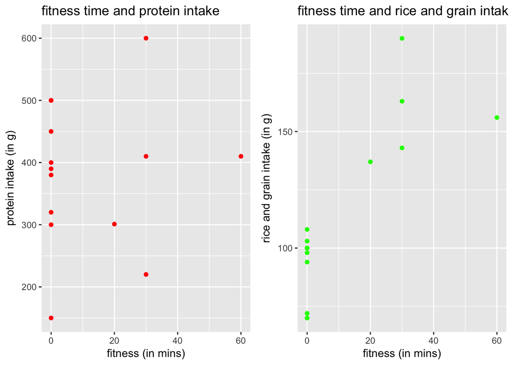

```r
ggplot_scatter()
```

Observations: From the scatter plot I can see that protein taken perday was still randomly distributed even if I did some exercises; However, I find that I eat more rice and grain when I did excercises: the average stays under 100 when fitness time is 0 and rice and grain intakes are greater than 100 if fitness time is larger than 0.

Explaination: This obervation explains the reason why the range of rice and grain is high, but the average is low. I don’t feel like eating them when I am not doing any sports (this is the normal case becuase I don’t often do exercises). But I will eat almost double rice and grain after going to the gym. This also explains that why the fitness time has positive correlation with my weight: I will eat more rice (almost double),which will increase my weight.

### Pvalue for Pearson’s correlation tests

Knowing these varibales may have positve or negative on my weight, I went to explore more about if these varibales can significantly influence on my weight. I did this by taking out the Pvalue from the correlation tests.

```r
MutiCorTestPvalue()
```

```
#> p-vlaue for correlation test between Weight (in kg) and Olive oil (in g) is
#> $p.value
#> [1] 0.7725316
#>
#> p-vlaue for correlation test between Weight (in kg) and Red Meat (in g) is
#> $p.value
#> [1] 0.637223
#>
#> p-vlaue for correlation test between Weight (in kg) and Other Proteins (in g) is
#> $p.value
#> [1] 0.05805242
#>
#> p-vlaue for correlation test between Weight (in kg) and Protein in total (in g) is
#> $p.value
#> [1] 0.001049264
#>
#> p-vlaue for correlation test between Weight (in kg) and Vegetables (in g) is
#> $p.value
#> [1] 0.01304455
#>
#> p-vlaue for correlation test between Weight (in kg) and Rice and Grain (in g) is
#> $p.value
#> [1] 0.9867274
#>
#> p-vlaue for correlation test between Weight (in kg) and Water (in cup) is
#> $p.value
#> [1] 0.0009392965
#>
#> p-vlaue for correlation test between Weight (in kg) and Snacks (in calories) is
#> $p.value
#> [1] 0.01536958
#>
#> p-vlaue for correlation test between Weight (in kg) and Fitness (in mins) is
#> $p.value
#> [1] 0.5203053
#>
#> p-vlaue for correlation test between Weight (in kg) and Entertament (in hrs) is
#> $p.value
#> [1] 0.4836885
#>
#> p-vlaue for correlation test between Weight (in kg) and Study Hours (in hrs) is
#> $p.value
#> [1] 0.5599833
#>
#> p-vlaue for correlation test between Weight (in kg) and Sleep Hours (in hrs) is
#> $p.value
#> [1] 0.6739076
```

For the Pearson’s correlation test, H0:correlation coefficient were in fact zero H1:correlation coefficient were not zero The pvalues between Weight (in kg) and Protein in total (in g), between Weight (in kg) and Vegetables (in g), between Weight (in kg) and Water (in cup) and between Weight (in kg) and Snacks (in calories) are <0.05. This indicates that their correlation coefficients are significant. However, for other pvalues>0.05, there is inconclusive evidence about the significance of the association between the variables.

### Multiple linear regression

Since I conclude that protein in total, vagetables, water and snacks are significanly correlated to my weight, I can build multiple linear regression model such that I can make prediction on my weight in the future.

```r
fit1 = lm(`Weight (in kg)`~ `Protein in total (in g)`+`Vegetables (in g)`+`Water (in cup)`+`Snacks (in calories)`, data=mydata)
summary(fit1)
```

```
#>
#> Call:
#> lm(formula = `Weight (in kg)` ~ `Protein in total (in g)` + `Vegetables (in g)` +
#>     `Water (in cup)` + `Snacks (in calories)`, data = mydata)
#>
#> Residuals:
#>      Min       1Q   Median       3Q      Max
#> -0.27834 -0.07602 -0.02246  0.05048  0.28330
#>
#> Coefficients:
#>                             Estimate Std. Error t value Pr(>|t|)
#> (Intercept)               61.6992913  0.6991040  88.255 8.53e-16 ***
#> `Protein in total (in g)`  0.0003059  0.0006926   0.442   0.6682
#> `Vegetables (in g)`       -0.0012039  0.0007746  -1.554   0.1512
#> `Water (in cup)`          -0.1517970  0.0627232  -2.420   0.0361 *
#> `Snacks (in calories)`     0.0012071  0.0007785   1.551   0.1521
#> ---
#> Signif. codes:  0 '***' 0.001 '**' 0.01 '*' 0.05 '.' 0.1 ' ' 1
#>
#> Residual standard error: 0.1644 on 10 degrees of freedom
#> Multiple R-squared:  0.7996, Adjusted R-squared:  0.7195
#> F-statistic: 9.977 on 4 and 10 DF,  p-value: 0.001614
```

### Multicollinearity?

I want to make sure that there is no multicollinearity in my modle. Therefore, I want to plot a correlation matrix.

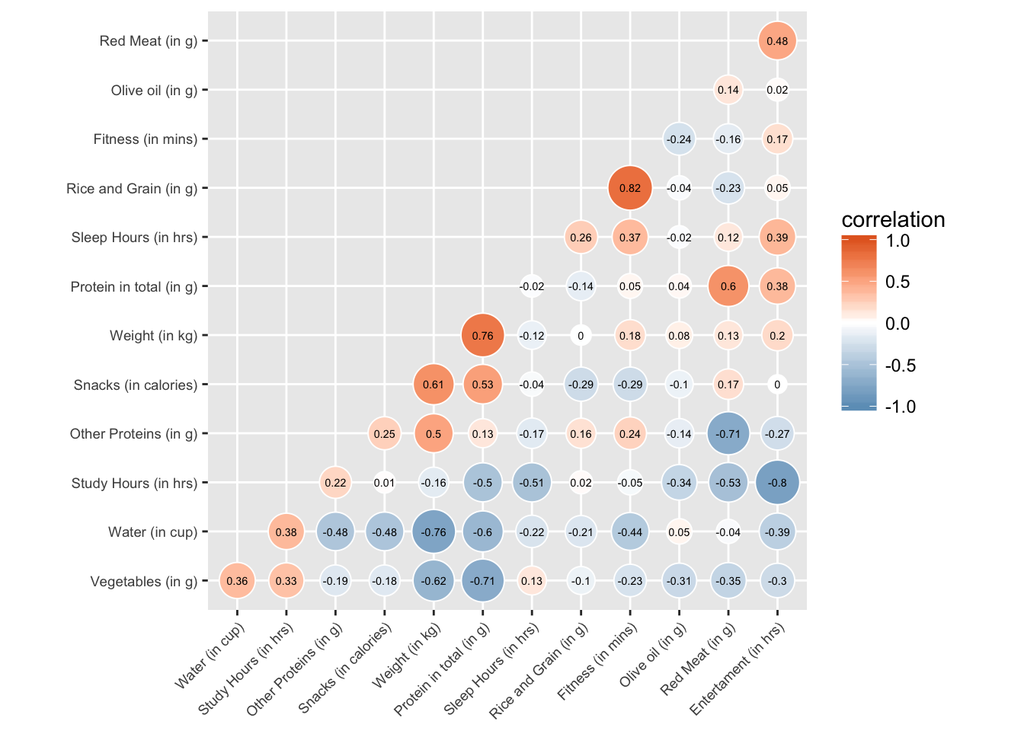

```r
library(ggcorrplot)
nums = sapply(mydata, is.numeric)
corr = cor(mydata[,nums])
ggcorrplot(corr, method="circle",hc.order = TRUE, type = "lower",
     outline.col = "white", ggtheme = ggplot2::theme_gray,
   colors = c("#6D9EC1", "white", "#E46726"),lab_size =1.9,lab=TRUE,legend.title = "correlation",tl.cex=7)
```

### Simple linear regression

```r
fit2=lm(mydata$`Vegetables (in g)` ~ mydata$`Protein in total (in g)`, data = mydata)
summary(fit2)
```

```
#>
#> Call:
#> lm(formula = mydata$`Vegetables (in g)` ~ mydata$`Protein in total (in g)`,
#>     data = mydata)
#>
#> Residuals:
#>     Min      1Q  Median      3Q     Max
#> -92.047 -61.370   2.401  50.532  99.740
#>
#> Coefficients:
#>                                  Estimate Std. Error t value Pr(>|t|)
#> (Intercept)                      605.5423    57.3309  10.562  9.5e-08 ***
#> mydata$`Protein in total (in g)`  -0.5159     0.1416  -3.643  0.00297 **
#> ---
#> Signif. codes:  0 '***' 0.001 '**' 0.01 '*' 0.05 '.' 0.1 ' ' 1
#>
#> Residual standard error: 62.11 on 13 degrees of freedom
#> Multiple R-squared:  0.5052, Adjusted R-squared:  0.4672
#> F-statistic: 13.27 on 1 and 13 DF,  p-value: 0.002975
```

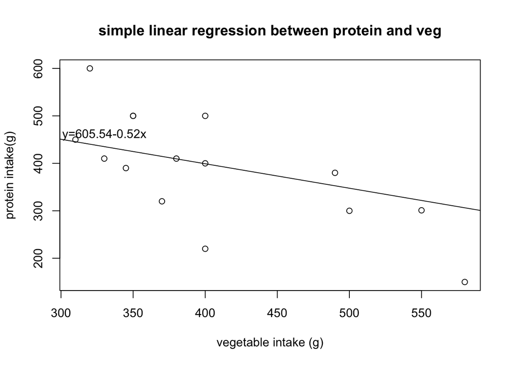

```r
plot(mydata$`Vegetables (in g)`,mydata$`Protein in total (in g)`,main="simple linear regression between protein and veg", xlab="vegetable intake (g)", ylab="protein intake(g)")
abline(lm(mydata$`Vegetables (in g)` ~ mydata$`Protein in total (in g)`, data = mydata))
text(x=330,y=460,"y=605.54-0.52x")
```

pvlaue for simple linear regression test <0.05.This indicates that their correlation coefficients are significant. This multicollinearity will result in unstable parameter estimates which makes it very difficult to assess the effect of vegetables and protein intake on my weight.

Now I need to consider if I want to drop one variavle from my linear model. However, looking at correlations only between vegetables and proteins is limiting. Significant correlation doesn’t mean I can drop the variable. I use variance inflation factors to help detect degree of multicollinearity in my model.

```r
library(fmsb)
VIF(lm(`Weight (in kg)`~ `Protein in total (in g)`+`Vegetables (in g)`+`Water (in cup)`+`Snacks (in calories)`, data=mydata))
```

```
#> [1] 4.990788
```

Since the VIF for this model is less than 5, multicolinearity is not strong. I will not drop variables from my original model. My final linear model is weight=61.6992913+0.0003059protein(inGram)-0.0012039veg(inGram)-0.1517970water(inCup)+0.0012071snacks(inCalories)

### Summary and Discussion

My eating habit looks stable and good: lots of vegetables, some protein, some grains and enough water perday. One bad thing is I don’t have stable eating habit in snacks that can increase my weight (outlier in snack intake boxplot). The other bad thing is I don’t keep a good habit of doing exercise. Also, by looking at scatter plot, I found that I like eating more rice and grains when I am doing exercise, which will increase my weight. Therefore, I need to both control my grain intake and do exercise if I want to lose weight. By looking at the P vlaue for correlation between my weight and other potential varibales, I conclude that protein in total, vagetables, water and snacks are significanly correlated to my weight. However, by looking at the correlation matrix, I found that there exists correlation between these variables. Vegetables and Proteins have negative and high correlation. But both of them will help exlain my weight. The right strategy to loose weight is eating more vegetables (that means less proteins).